# Visulization

William Tomaszeswki, Jonathan Perera

2022-07-25

## I. Setup

### Loading the Required Packages

Please install and load the following packages. If not installed use the corresponding links given.

```r
#BiocManager::install("Seurat")
library(tidyverse)
library(Seurat)
library(patchwork)
library(viridis)
library(readxl)
library(scater)
library(biomaRt)
library(zen4R)
library(ggplot2)
library(gridExtra)
library(EnhancedVolcano)
library(kableExtra)
library(stringr)
library(EnhancedVolcano)
library(Nebulosa)
```

## II. Loading in seurat object

The Seurat object used in the paper can be accessed under zenodo accession 6654420.

```r
download_zenodo("10.5281/zenodo.6654420",files = "Processed_CD45_Live_Fig2b.rds")
m.ct2a <- readRDS("Processed_CD45_Live_Fig2b.rds")
Idents(m.ct2a) <- m.ct2a$Cell.Type
```

## III. Visualization

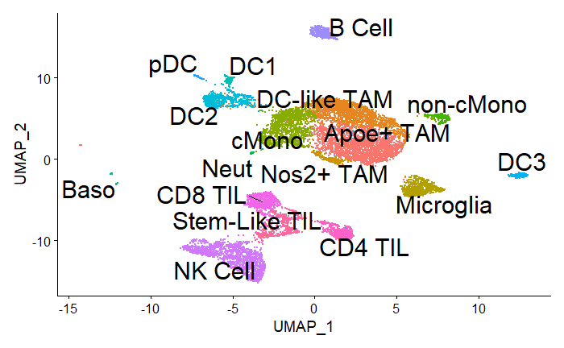

```r
DimPlot(m.ct2a, label = T, repel = T,label.size = 8) + theme(legend.position = "none")
ggsave("m.ct2a_dimplot.pdf",device = "pdf", width = 2, height = 2, units = "in", scale = 6)
```

Here we split the data set by Genotype (labelled here, WT and CaMKK2) (Fig. 2b)

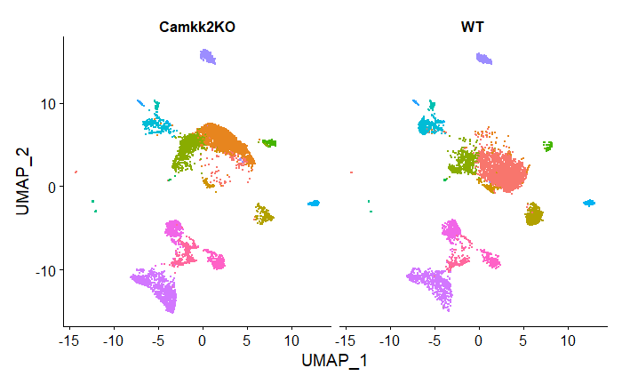

```r
DimPlot(m.ct2a, split.by = "Genotype") + theme(legend.position = "none")
```

Expression here visualized for each cluster for a selected list of genes (Fig. 2d)

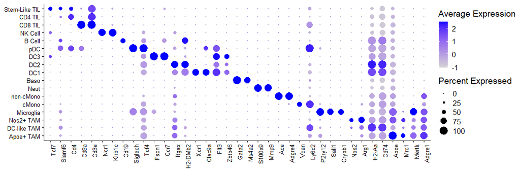

Here we split the data set by Mouse ID.

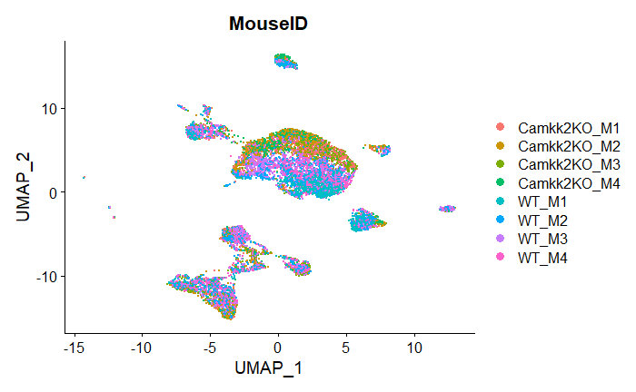

```r
DimPlot(m.ct2a, repel = T, group.by = "MouseID")
```

```r
table(m.ct2a$MouseID)
```

```
Camkk2KO_M1 Camkk2KO_M2 Camkk2KO_M3 Camkk2KO_M4       WT_M1       WT_M2       WT_M3       WT_M4
       1382        1783        1652        1178        1361        1437        1467        1524
```

#Iba1 Vln Plot (SF4.f)

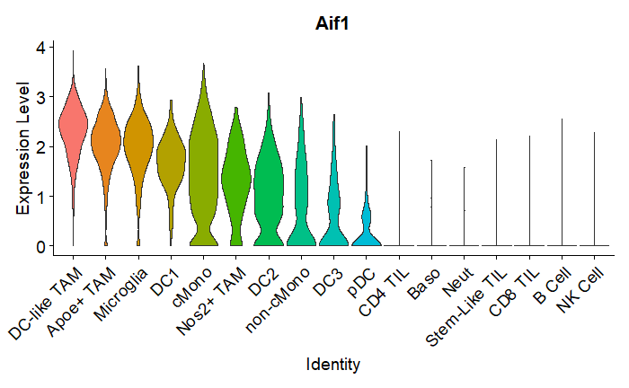

```r
VlnPlot(m.ct2a, features = "Aif1", assay = "RNA", sort = "increasing", pt.size = 0) +
  theme(legend.position = "none", text = element_text(size = 14), axis.text = element_text(size = 14))
```

## IV. Differential Expression Genotypes

We then performed differential expression analysis on the following cell types between their genotypic identities (WT vs CaMKK2 KO)

```r
#####
diffgenolist <- c("Microglia",
                  "cMono","non-cMono","Neut","Baso",
                  "DC1","DC2","DC3","pDC",
                  "B Cell","NK Cell")

Idents(m.ct2a) <- m.ct2a$Geno.Ident
lev <- levels(Idents(m.ct2a))
lev <- lev[order(lev)]
lev[c(2,3,6,8,9,10,11,12,13,14,16)]
```

```
 [1] "Camkk2KO_B Cell"    "Camkk2KO_Baso"      "Camkk2KO_cMono"     "Camkk2KO_DC1"       "Camkk2KO_DC2"
 [6] "Camkk2KO_DC3"       "Camkk2KO_Microglia" "Camkk2KO_Neut"      "Camkk2KO_NK Cell"   "Camkk2KO_non-cMono"
[11] "Camkk2KO_pDC"
```

Using the same FindMarkers function, we compare the WT and KO expression signatures for the following cell types: Microglia, cMono, non-cMono, Neut, Baso, DC1, DC2, DC3, pDC, B Cell, NK Cell.

```r
#BiocManager::install("MAST")
g.markers <- lapply(c(2,3,6,8,9,10,11,12,13,14,16), function(i){
  FindMarkers(m.ct2a, ident.1 = lev[i], ident.2 =  lev[i+17], min.pct = .1, test.use = "MAST", verbose = T, assay = "RNA")
})
```

### B cell

```r
#BiocManager::install("EnhancedVolcano")

lev[2]
```

```
[1] "Camkk2KO_B Cell"
```

```r
g.markers[[1]][1:100,]
```

|  | p_val | avg_log2FC | pct.1 | pct.2 | p_val_adj |
| --- | --- | --- | --- | --- | --- |
| Apoe | 3.994398e-70 | -2.0246996 | 0.206 | 0.962 | 7.230260e-66 |
| Gm8797 | 5.561972e-38 | 1.2856075 | 0.626 | 0.043 | 1.006773e-33 |
| Ifi27l2a | 1.019577e-23 | 1.6884008 | 0.888 | 0.575 | 1.845537e-19 |
| Psmb9 | 3.036883e-21 | 1.1818419 | 0.808 | 0.425 | 5.497063e-17 |
| Actb | 6.217575e-21 | 0.7921312 | 1.000 | 1.000 | 1.125443e-16 |
| Rnf213 | 6.502971e-19 | 1.2127451 | 0.542 | 0.129 | 1.177103e-14 |
| Ifi47 | 1.373175e-18 | 1.4800001 | 0.607 | 0.194 | 2.485583e-14 |
| Pfn1 | 3.232062e-18 | 0.8819174 | 0.986 | 0.914 | 5.850355e-14 |
| Ubc | 1.908767e-17 | -0.8713122 | 0.780 | 0.860 | 3.455060e-13 |
| Ppa1 | 4.031327e-17 | 1.0904043 | 0.397 | 0.065 | 7.297106e-13 |

[output cut: 90 more lines]

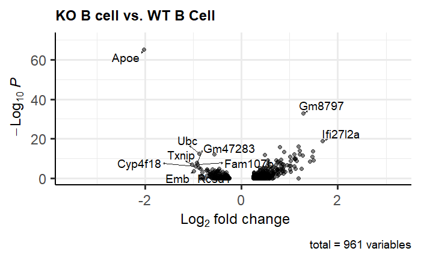

```r
EnhancedVolcano(g.markers[[1]],lab=rownames(g.markers[[1]]),x="avg_log2FC",y="p_val_adj",
                selectLab = (rownames(g.markers[[1]] %>% slice_max(n = 40, order_by = abs(avg_log2FC)))),
                pCutoff = NA,FCcutoff = NA,drawConnectors = T, title = "KO B cell vs. WT B Cell",
                subtitle = NULL, legendPosition = "none", col = c("black","black","black","red"))
```

### Baso - no DEGs

```r
lev[3]
```

```
[1] "Camkk2KO_Baso"
```

```r
g.markers[[2]][1:100,]
```

|  | p_val | avg_log2FC | pct.1 | pct.2 | p_val_adj |
| --- | --- | --- | --- | --- | --- |
| Gm8797 | 4.554355e-05 | 2.1018765 | 0.783 | 0.077 | 0.8243838 |
| Apoe | 7.327349e-05 | -3.6413458 | 0.217 | 0.846 | 1.0000000 |
| Furin | 2.977752e-04 | -1.5038286 | 1.000 | 1.000 | 1.0000000 |
| Sec61g | 5.143590e-04 | 1.2077736 | 1.000 | 0.692 | 1.0000000 |
| Acat1 | 7.240706e-04 | 0.7283409 | 0.478 | 0.000 | 1.0000000 |
| Zfp68 | 1.156519e-03 | -0.4740483 | 0.000 | 0.385 | 1.0000000 |
| Bri3bp | 1.156519e-03 | -0.6147803 | 0.000 | 0.385 | 1.0000000 |
| Cnot6l | 1.392470e-03 | -1.1551893 | 0.348 | 0.846 | 1.0000000 |
| Dnaja1 | 1.487792e-03 | -1.3484874 | 0.913 | 0.846 | 1.0000000 |
| Nubp1 | 1.527581e-03 | 0.5497981 | 0.435 | 0.000 | 1.0000000 |

[output cut: 90 more lines]

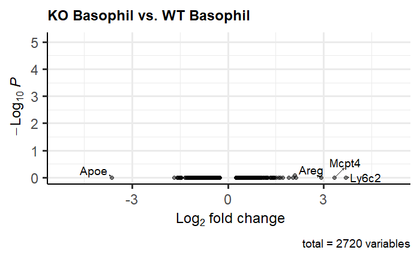

```r
EnhancedVolcano(g.markers[[2]],lab=rownames(g.markers[[2]]),x="avg_log2FC",y="p_val_adj",
                selectLab = (rownames(g.markers[[2]] %>% slice_max(n = 40, order_by = abs(avg_log2FC)))),
                pCutoff = NA,FCcutoff = NA,drawConnectors = T, title = "KO Basophil vs. WT Basophil",
                subtitle = NULL, legendPosition = "none", col = c("black","black","black","red"))
```

### cMono

```r
lev[6]
```

```
[1] "Camkk2KO_cMono"
```

```r
g.markers[[3]][1:100,]
```

|  | p_val | avg_log2FC | pct.1 | pct.2 | p_val_adj |
| --- | --- | --- | --- | --- | --- |
| Ifi202b | 0.000000e+00 | 3.1390531 | 0.974 | 0.000 | 0.000000e+00 |
| Ifi44l | 0.000000e+00 | 2.3362133 | 0.913 | 0.000 | 0.000000e+00 |
| Ifi44 | 9.853448e-319 | 3.0373599 | 0.936 | 0.052 | 1.783573e-314 |
| Apoe | 2.545438e-313 | -3.7663051 | 0.406 | 0.998 | 4.607497e-309 |
| Gm8797 | 5.547655e-212 | 1.3158772 | 0.800 | 0.051 | 1.004181e-207 |
| Gatm | 6.617287e-194 | 2.2330169 | 0.877 | 0.182 | 1.197795e-189 |
| Hebp1 | 1.420142e-180 | 1.3886027 | 0.759 | 0.062 | 2.570600e-176 |
| Spint1 | 3.028125e-170 | -1.7704063 | 0.002 | 0.576 | 5.481208e-166 |
| Ifi213 | 2.478537e-143 | -1.4911466 | 0.055 | 0.620 | 4.486400e-139 |
| Ncf4 | 1.095403e-134 | 1.0094850 | 0.992 | 0.919 | 1.982788e-130 |

[output cut: 90 more lines]

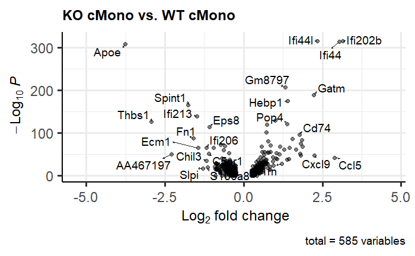

```r
EnhancedVolcano(g.markers[[3]],lab=rownames(g.markers[[3]]),x="avg_log2FC",y="p_val_adj",
                selectLab = (rownames(g.markers[[3]] %>% slice_max(n = 40, order_by = abs(avg_log2FC)))),
                pCutoff = NA,FCcutoff = NA,drawConnectors = T, title = "KO cMono vs. WT cMono",
                subtitle = NULL, legendPosition = "none", col = c("black","black","black","red"))
```

### DC1

```r
lev[8]
```

```
[1] "Camkk2KO_DC1"
```

```r
g.markers[[4]][1:100,]
```

|  | p_val | avg_log2FC | pct.1 | pct.2 | p_val_adj |
| --- | --- | --- | --- | --- | --- |
| Gm8797 | 1.556756e-31 | 1.3453816 | 0.981 | 0.119 | 2.817884e-27 |
| Ifi202b | 7.011082e-27 | 1.7776350 | 0.808 | 0.000 | 1.269076e-22 |
| Ifi44l | 7.011082e-27 | 1.6516323 | 0.808 | 0.000 | 1.269076e-22 |
| Spint1 | 1.313734e-26 | -1.3029114 | 0.000 | 0.845 | 2.377989e-22 |
| Apoe | 7.038578e-24 | -1.9406491 | 0.288 | 0.976 | 1.274053e-19 |
| Wls | 1.587412e-20 | 1.3271721 | 0.788 | 0.048 | 2.873375e-16 |
| Ifi205 | 6.179735e-17 | -1.5790889 | 0.904 | 1.000 | 1.118594e-12 |
| Gm47283 | 1.552118e-14 | -1.2935888 | 0.288 | 0.845 | 2.809488e-10 |
| Ncf4 | 3.118052e-14 | 0.9103287 | 0.962 | 0.881 | 5.643985e-10 |
| Ubc | 1.190605e-12 | -1.1598865 | 0.942 | 1.000 | 2.155114e-08 |

[output cut: 90 more lines]

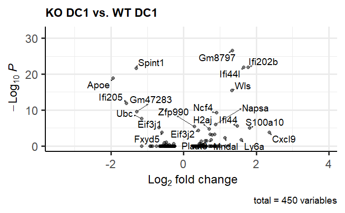

```r
EnhancedVolcano(g.markers[[4]],lab=rownames(g.markers[[4]]),x="avg_log2FC",y="p_val_adj",
                selectLab = (rownames(g.markers[[4]] %>% slice_min(n = 25, order_by = p_val_adj))),
                pCutoff = NA,FCcutoff = NA,drawConnectors = T, title = "KO DC1 vs. WT DC1",
                subtitle = NULL, legendPosition = "none", col = c("black","black","black","red"))
```

### DC2

```r
lev[9]
```

```
[1] "Camkk2KO_DC2"
```

```r
g.markers[[5]][1:100,]
```

|  | p_val | avg_log2FC | pct.1 | pct.2 | p_val_adj |
| --- | --- | --- | --- | --- | --- |
| Spint1 | 9.123620e-133 | -1.8698929 | 0.027 | 0.924 | 1.651466e-128 |
| Ifi202b | 9.144253e-113 | 1.8596188 | 0.764 | 0.000 | 1.655201e-108 |
| Gm8797 | 6.305326e-108 | 1.2627653 | 0.884 | 0.115 | 1.141327e-103 |
| Apoe | 1.083940e-105 | -1.8825968 | 0.227 | 0.970 | 1.962040e-101 |
| Ifi44l | 2.308856e-104 | 1.6309721 | 0.724 | 0.000 | 4.179260e-100 |
| Wls | 3.692568e-77 | 1.6100542 | 0.827 | 0.241 | 6.683917e-73 |
| Ubc | 1.039181e-66 | -1.1110634 | 0.938 | 0.995 | 1.881021e-62 |
| S100a10 | 3.300707e-60 | 1.5380720 | 0.956 | 0.779 | 5.974610e-56 |
| Ifi44 | 8.107201e-58 | 1.7718022 | 0.818 | 0.283 | 1.467484e-53 |
| Gm47283 | 1.095327e-48 | -0.9729690 | 0.244 | 0.791 | 1.982652e-44 |

[output cut: 90 more lines]

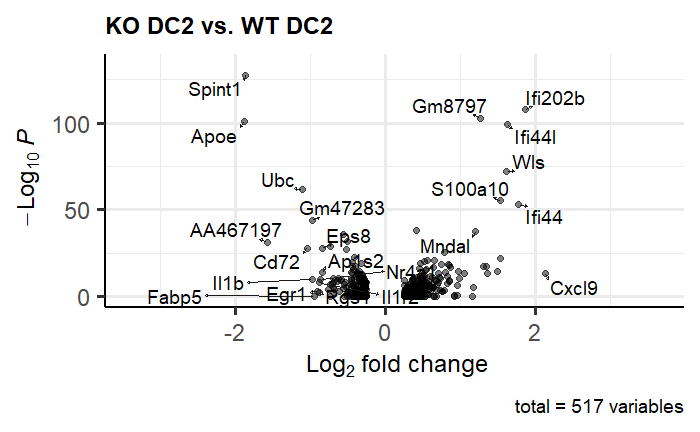

```r
EnhancedVolcano(g.markers[[5]],lab=rownames(g.markers[[5]]),x="avg_log2FC",y="p_val_adj",
                selectLab = (rownames(g.markers[[5]] %>% slice_max(n = 45, order_by = abs(avg_log2FC)))),
                pCutoff = NA,FCcutoff = NA,drawConnectors = T, title = "KO DC2 vs. WT DC2",
                subtitle = NULL, legendPosition = "none", col = c("black","black","black","red"))
```

### DC3

```r
lev[10]
```

```
[1] "Camkk2KO_DC3"
```

```r
g.markers[[6]][1:100,]
```

|  | p_val | avg_log2FC | pct.1 | pct.2 | p_val_adj |
| --- | --- | --- | --- | --- | --- |
| Apoe | 5.632821e-27 | -1.1705514 | 0.211 | 0.945 | 1.019597e-22 |
| Gm8797 | 6.070291e-27 | 1.4518863 | 0.835 | 0.096 | 1.098783e-22 |
| Ext1 | 3.473905e-18 | -1.0172955 | 0.009 | 0.534 | 6.288116e-14 |
| Ubc | 1.216896e-15 | -1.0640105 | 0.972 | 0.986 | 2.202703e-11 |
| Rplp0 | 8.433858e-13 | -0.9258424 | 0.991 | 0.973 | 1.526613e-08 |
| Got1 | 3.489714e-12 | -1.2440702 | 0.615 | 0.877 | 6.316732e-08 |
| H2-D1 | 1.874827e-10 | 0.5280226 | 1.000 | 1.000 | 3.393624e-06 |
| Rpl21 | 1.445051e-09 | -0.7362932 | 0.963 | 0.973 | 2.615687e-05 |
| Ifi202b | 3.822749e-09 | 0.7532029 | 0.284 | 0.000 | 6.919557e-05 |
| Rps28 | 1.665246e-08 | -0.8224748 | 0.963 | 0.986 | 3.014262e-04 |

[output cut: 90 more lines]

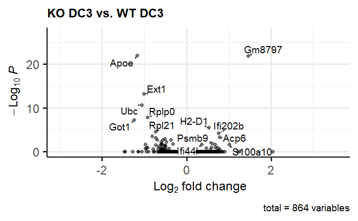

```r
EnhancedVolcano(g.markers[[6]],lab=rownames(g.markers[[6]]),x="avg_log2FC",y="p_val_adj",
                selectLab = (rownames(g.markers[[6]] %>% slice_min(n = 25, order_by = p_val_adj))),
                pCutoff = NA,FCcutoff = NA,drawConnectors = T, title = "KO DC3 vs. WT DC3",
                subtitle = NULL, legendPosition = "none", col = c("black","black","black","red"))
```

### Microglia

```r
lev[11]
```

```
[1] "Camkk2KO_Microglia"
```

```r
g.markers[[7]][1:100,]
```

|  | p_val | avg_log2FC | pct.1 | pct.2 | p_val_adj |
| --- | --- | --- | --- | --- | --- |
| Gatm | 4.512654e-137 | 2.0302723 | 1.000 | 0.759 | 8.168356e-133 |
| Ifi202b | 1.620701e-135 | 1.8342985 | 0.856 | 0.000 | 2.933631e-131 |
| Fcrls | 6.505340e-120 | -2.9334587 | 0.213 | 0.963 | 1.177532e-115 |
| Ifi44 | 2.081323e-102 | 1.8856184 | 0.856 | 0.087 | 3.767403e-98 |
| Cd74 | 3.982415e-101 | 3.3767952 | 0.995 | 0.852 | 7.208569e-97 |
| Spint1 | 2.071034e-100 | -1.6516758 | 0.009 | 0.805 | 3.748778e-96 |
| Ifi44l | 5.611659e-95 | 1.1400477 | 0.671 | 0.000 | 1.015766e-90 |
| Gm8797 | 6.543805e-91 | 1.2493806 | 0.847 | 0.115 | 1.184494e-86 |
| H2-Eb1 | 8.944123e-83 | 3.0709639 | 0.944 | 0.527 | 1.618976e-78 |
| H2-Aa | 4.017667e-82 | 3.0858056 | 0.954 | 0.510 | 7.272378e-78 |

[output cut: 90 more lines]

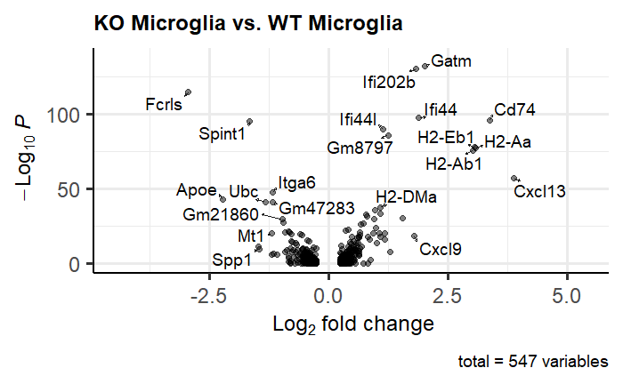

```r
EnhancedVolcano(g.markers[[7]],lab=rownames(g.markers[[7]]),x="avg_log2FC",y="p_val_adj",
                selectLab = (c(rownames(g.markers[[7]] %>% slice_min(n = 50, order_by = p_val_adj)),"Spp1")),
                pCutoff = NA,FCcutoff = NA,drawConnectors = T, title = "KO Microglia vs. WT Microglia",
                subtitle = NULL, legendPosition = "none", col = c("black","black","black","red"))
```

### Neutrophil - NO DEGs

```r
lev[12]
```

```
[1] "Camkk2KO_Neut"
```

```r
g.markers[[8]][1:100,]
```

|  | p_val | avg_log2FC | pct.1 | pct.2 | p_val_adj |
| --- | --- | --- | --- | --- | --- |
| Apoe | 8.482998e-05 | -2.7124936 | 0.250 | 0.933 | 1 |
| Gm8797 | 1.617351e-04 | 2.0026467 | 0.562 | 0.000 | 1 |
| Nampt | 7.823233e-04 | -1.7690285 | 0.000 | 0.467 | 1 |
| Prnp | 7.823233e-04 | -1.9446621 | 0.000 | 0.467 | 1 |
| Actr2 | 1.004047e-03 | 1.4499785 | 1.000 | 0.533 | 1 |
| Hacd4 | 1.457231e-03 | 1.5682855 | 0.438 | 0.000 | 1 |
| Entpd1 | 1.647998e-03 | -0.9917721 | 0.250 | 0.867 | 1 |
| Eny2 | 2.373619e-03 | -0.9874523 | 0.000 | 0.400 | 1 |
| Gpr146 | 2.373619e-03 | -1.7459751 | 0.000 | 0.400 | 1 |
| Oasl2 | 2.373619e-03 | -1.4695860 | 0.000 | 0.400 | 1 |

[output cut: 90 more lines]

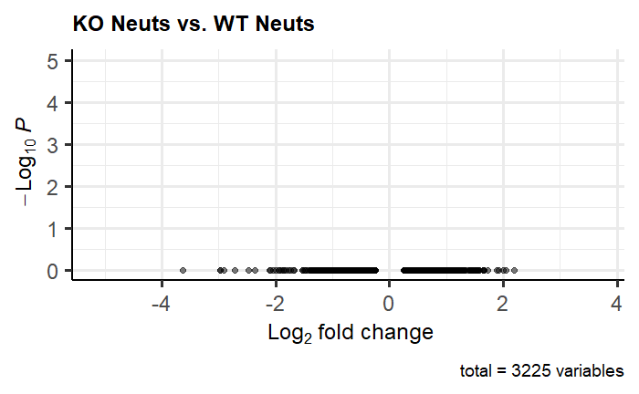

```r
EnhancedVolcano(g.markers[[8]],lab=rownames(g.markers[[8]]),x="avg_log2FC",y="p_val_adj",
                selectLab = (c(rownames(g.markers[[8]] %>% slice_min(n = 50, order_by = p_val_adj)))),
                pCutoff = NA,FCcutoff = NA,drawConnectors = T, title = "KO Neuts vs. WT Neuts",
                subtitle = NULL, legendPosition = "none", col = c("black","black","black","red"))
```

### NK Cells

```r
lev[13]
```

```
[1] "Camkk2KO_NK Cell"
```

```r
g.markers[[9]][1:100,]
```

|  | p_val | avg_log2FC | pct.1 | pct.2 | p_val_adj |
| --- | --- | --- | --- | --- | --- |
| Wls | 5.632005e-288 | 2.3507907 | 0.944 | 0.317 | 1.019449e-283 |
| Apoe | 1.019270e-287 | -2.0068244 | 0.197 | 0.957 | 1.844980e-283 |
| Gm2682 | 6.683524e-189 | -1.2314914 | 0.004 | 0.599 | 1.209785e-184 |
| Gm8797 | 3.460967e-188 | 1.3960316 | 0.724 | 0.082 | 6.264696e-184 |
| Gm47283 | 5.933159e-154 | -1.4493072 | 0.182 | 0.774 | 1.073961e-149 |
| Rps3a1 | 1.086959e-127 | -0.7540133 | 0.995 | 0.999 | 1.967504e-123 |
| Eif3j1 | 1.224023e-94 | -0.8652204 | 0.183 | 0.666 | 2.215604e-90 |
| Rpl21 | 3.710340e-89 | -0.6180420 | 0.992 | 1.000 | 6.716086e-85 |
| Zfp990 | 1.055926e-77 | 0.5008514 | 0.310 | 0.001 | 1.911333e-73 |
| Eif3j2 | 1.906202e-72 | 0.6128568 | 0.385 | 0.046 | 3.450417e-68 |

[output cut: 90 more lines]

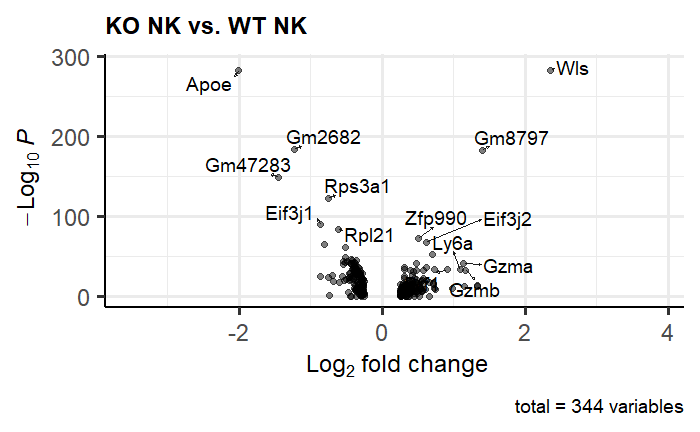

```r
EnhancedVolcano(g.markers[[9]],lab=rownames(g.markers[[9]]),x="avg_log2FC",y="p_val_adj",
                selectLab = (c(rownames(g.markers[[9]] %>% slice_min(n = 50, order_by = p_val_adj)))),
                pCutoff = NA,FCcutoff = NA,drawConnectors = T, title = "KO NK vs. WT NK",
                subtitle = NULL, legendPosition = "none", col = c("black","black","black","red"))
```

### non-cMono

```r
lev[14]
```

```
[1] "Camkk2KO_non-cMono"
```

```r
g.markers[[10]][1:100,]
```

|  | p_val | avg_log2FC | pct.1 | pct.2 | p_val_adj |
| --- | --- | --- | --- | --- | --- |
| Apoe | 1.187249e-44 | -3.8033957 | 0.528 | 1.000 | 2.149040e-40 |
| Gm8797 | 4.711794e-25 | 1.4680095 | 0.715 | 0.014 | 8.528818e-21 |
| Cd74 | 9.814420e-25 | 2.2259832 | 1.000 | 0.789 | 1.776508e-20 |
| Ifi202b | 1.164267e-19 | 1.4109941 | 0.561 | 0.000 | 2.107441e-15 |
| H2-Eb1 | 6.239990e-17 | 2.2951279 | 0.886 | 0.310 | 1.129501e-12 |
| H2-Aa | 1.063538e-15 | 2.0900168 | 0.870 | 0.324 | 1.925110e-11 |
| H2-Ab1 | 3.872173e-15 | 2.3883932 | 0.911 | 0.465 | 7.009021e-11 |
| Hpgd | 3.979873e-15 | -1.9113972 | 0.024 | 0.493 | 7.203967e-11 |
| Ifi44 | 1.763280e-14 | 1.3668632 | 0.496 | 0.014 | 3.191713e-10 |
| Fkbp5 | 7.248443e-12 | -1.1806153 | 0.390 | 0.817 | 1.312041e-07 |

[output cut: 90 more lines]

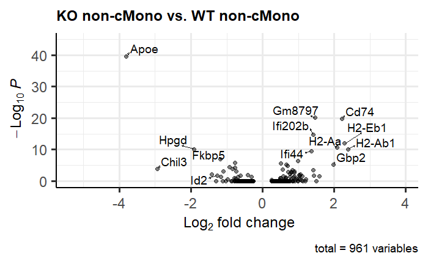

```r
EnhancedVolcano(g.markers[[10]],lab=rownames(g.markers[[10]]),x="avg_log2FC",y="p_val_adj",
                selectLab = (c(rownames(g.markers[[10]] %>% slice_min(n = 50, order_by = p_val_adj)))),
                pCutoff = NA,FCcutoff = NA,drawConnectors = T, title = "KO non-cMono vs. WT non-cMono",
                subtitle = NULL, legendPosition = "none", col = c("black","black","black","red"))
```

### pDC

```r
lev[16]
```

```
[1] "Camkk2KO_pDC"
```

```r
g.markers[[11]][1:100,]
```

|  | p_val | avg_log2FC | pct.1 | pct.2 | p_val_adj |
| --- | --- | --- | --- | --- | --- |
| Apoe | 7.689382e-19 | -2.4104088 | 0.178 | 1.000 | 1.391855e-14 |
| Wls | 1.368551e-11 | 1.5263876 | 0.756 | 0.053 | 2.477213e-07 |
| Gm8797 | 1.953087e-11 | 1.2916501 | 0.822 | 0.158 | 3.535283e-07 |
| Ifi44l | 1.999511e-11 | 1.2850153 | 0.622 | 0.000 | 3.619316e-07 |
| Ubc | 2.435785e-08 | -1.3327412 | 0.956 | 0.974 | 4.409014e-04 |
| Gm47283 | 8.667855e-08 | -1.1197485 | 0.089 | 0.632 | 1.568969e-03 |
| Rnf187 | 1.628886e-07 | -1.0620175 | 0.667 | 0.868 | 2.948446e-03 |
| Khk | 3.649824e-07 | -0.8813476 | 0.422 | 0.921 | 6.606547e-03 |
| Tcf4 | 3.008025e-06 | 0.5851986 | 1.000 | 1.000 | 5.444827e-02 |
| Ctse | 3.176241e-06 | 0.9453010 | 0.533 | 0.053 | 5.749315e-02 |

[output cut: 90 more lines]

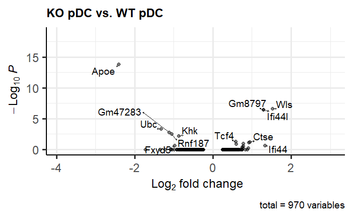

```r
EnhancedVolcano(g.markers[[11]],lab=rownames(g.markers[[11]]),x="avg_log2FC",y="p_val_adj",
                selectLab = (c(rownames(g.markers[[11]] %>% slice_min(n = 18, order_by = p_val_adj)))),
                pCutoff = NA,FCcutoff = NA,drawConnectors = T, title = "KO pDC vs. WT pDC",
                subtitle = NULL, legendPosition = "none", col = c("black","black","black","red"))
```

### Cell Type Frequency and Proportions

```r
#All Cell Type Heatmap
Idents(m.ct2a) <- m.ct2a$Geno.Ident
ct2a.avg <- AverageExpression(m.ct2a,assays = "RNA",add.ident = "hash.ID", return.seurat = T)
```

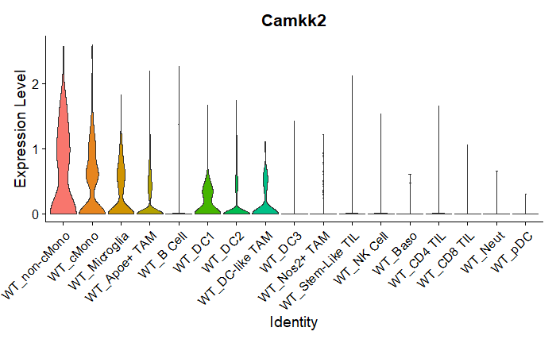

```r
#CaMKK2 Counts
counts <- GetAssayData(m.ct2a, slot = "data", assay = "RNA")
camkk2.counts <- counts["Camkk2",]
camkk2 <- data.frame(counts = camkk2.counts, Genotype = m.ct2a$Genotype, Celltype = Idents(m.ct2a))

#SF 2b
VlnPlot(subset(m.ct2a, subset = Genotype == "WT"),features = "Camkk2", assay = "RNA", sort = "increasing", pt.size = 0) + theme(legend.position = "none")
```

Plotting cell frequency

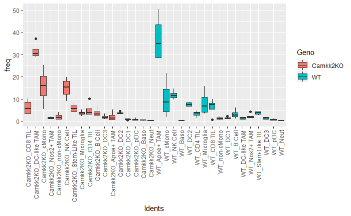

```r
meta <- m.ct2a@meta.data
idents <- m.ct2a@active.ident
meta <- meta[,c("Genotype","MouseID","HTO_maxID")]
meta <- meta %>% add_column(Idents = idents)
meta[,(c("Genotype","MouseID","HTO_maxID"))] <- lapply(meta[,(c("Genotype","MouseID","HTO_maxID"))], as.factor)

meta1 <- meta %>% group_by(MouseID,Idents) %>% summarise(n = n()) %>% mutate(freq =  prop.table(n)*100)
geno <- c(rep("Camkk2KO",67),rep("WT",66))

ungroup(meta1) %>% mutate(Geno = geno) %>% ggplot(aes(Idents,freq,fill=Geno)) + geom_boxplot(position = position_dodge()) + theme(axis.text.x = element_text(angle = 90, vjust = 0.5, hjust=1))
```

```r
Cell_freq <- ungroup(meta1) %>% mutate(Geno = geno)
write_excel_csv(Cell_freq,"Cell_freq.csv")
```

Proportion Table

```r
prop.table(table(Idents(m.ct2a),m.ct2a$MouseID),margin = 2)*100
```

```
                         Camkk2KO_M1 Camkk2KO_M2 Camkk2KO_M3 Camkk2KO_M4       WT_M1       WT_M2       WT_M3       WT_M4
  Camkk2KO_CD8 TIL       10.05788712  3.36511497  7.99031477  3.31069610  0.00000000  0.00000000  0.00000000  0.00000000
  Camkk2KO_DC-like TAM   37.19247467 29.66909703 28.81355932 30.98471986  0.00000000  0.00000000  0.00000000  0.00000000
  Camkk2KO_cMono         13.53111433 18.50813236  5.50847458 25.29711375  0.00000000  0.00000000  0.00000000  0.00000000
  Camkk2KO_Nos2+ TAM      1.08538350  2.29949523  1.39225182  0.00000000  0.00000000  0.00000000  0.00000000  0.00000000
  Camkk2KO_non-cMono      1.08538350  4.03813797  0.60532688  2.20713073  0.00000000  0.00000000  0.00000000  0.00000000
  Camkk2KO_NK Cell       13.24167873 17.33034212 19.85472155  9.08319185  0.00000000  0.00000000  0.00000000  0.00000000
  Camkk2KO_Stem-Like TIL  4.26917511  8.24453169  4.35835351  6.70628183  0.00000000  0.00000000  0.00000000  0.00000000
  Camkk2KO_Microglia      3.54558611  2.24340998  5.08474576  3.65025467  0.00000000  0.00000000  0.00000000  0.00000000
  Camkk2KO_CD4 TIL        4.26917511  3.19685923 10.10895884  2.97113752  0.00000000  0.00000000  0.00000000  0.00000000
  Camkk2KO_B Cell         2.89435601  3.53337072  1.75544794  6.96095076  0.00000000  0.00000000  0.00000000  0.00000000
  Camkk2KO_DC3            0.94066570  1.85081324  1.45278450  3.31069610  0.00000000  0.00000000  0.00000000  0.00000000
  Camkk2KO_Apoe+ TAM      1.95369030  0.61693775  5.14527845  0.67911715  0.00000000  0.00000000  0.00000000  0.00000000
  Camkk2KO_DC2            3.54558611  3.42120022  4.60048426  3.31069610  0.00000000  0.00000000  0.00000000  0.00000000
  Camkk2KO_DC1            1.01302460  1.00953449  0.90799031  0.42444822  0.00000000  0.00000000  0.00000000  0.00000000
  Camkk2KO_pDC            0.65123010  0.50476725  1.51331719  0.16977929  0.00000000  0.00000000  0.00000000  0.00000000
  Camkk2KO_Baso           0.50651230  0.11217050  0.42372881  0.59422750  0.00000000  0.00000000  0.00000000  0.00000000
  Camkk2KO_Neut           0.21707670  0.05608525  0.48426150  0.33955857  0.00000000  0.00000000  0.00000000  0.00000000
  WT_Apoe+ TAM            0.00000000  0.00000000  0.00000000  0.00000000 50.47759001 28.67084203 28.56169052 41.14173228
  WT_cMono                0.00000000  0.00000000  0.00000000  0.00000000  1.91036003 12.03897008 21.54055896  5.05249344
  WT_NK Cell              0.00000000  0.00000000  0.00000000  0.00000000  9.77222630 11.96938065 10.97477846 14.76377953
  WT_Baso                 0.00000000  0.00000000  0.00000000  0.00000000  0.00000000  0.13917884  0.34083163  0.39370079
  WT_DC2                  0.00000000  0.00000000  0.00000000  0.00000000  8.15576782  6.81976340  6.47580095  8.59580052
  WT_CD4 TIL              0.00000000  0.00000000  0.00000000  0.00000000  1.32255694  3.82741823  3.20381731  4.79002625
  WT_Microglia            0.00000000  0.00000000  0.00000000  0.00000000 15.79720794  9.11621434  3.47648262  4.19947507
  WT_CD8 TIL              0.00000000  0.00000000  0.00000000  0.00000000  0.73475386  7.58524704  9.88411725  7.08661417
  WT_non-cMono            0.00000000  0.00000000  0.00000000  0.00000000  0.44085231  2.22686152  1.22699387  0.98425197
  WT_DC1                  0.00000000  0.00000000  0.00000000  0.00000000  1.10213079  1.32219903  1.02249489  2.29658793
  WT_B Cell               0.00000000  0.00000000  0.00000000  0.00000000  2.42468773  6.12386917  3.20381731  1.18110236
  WT_DC-like TAM          0.00000000  0.00000000  0.00000000  0.00000000  0.14695077  1.25260960  2.11315610  1.57480315
  WT_Nos2+ TAM            0.00000000  0.00000000  0.00000000  0.00000000  4.18809699  1.73973556  1.70415815  1.64041995
  WT_Stem-Like TIL        0.00000000  0.00000000  0.00000000  0.00000000  2.64511389  3.40988170  4.22631220  4.33070866
  WT_DC3                  0.00000000  0.00000000  0.00000000  0.00000000  0.36737693  1.87891441  1.63599182  1.11548556
  WT_pDC                  0.00000000  0.00000000  0.00000000  0.00000000  0.22042616  1.18302018  0.40899796  0.78740157
  WT_Neut                 0.00000000  0.00000000  0.00000000  0.00000000  0.29390154  0.69589422  0.00000000  0.06561680
```

### TAM DEGs

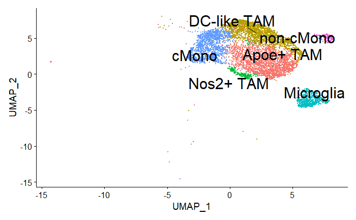

```r
Idents(m.ct2a) <- m.ct2a$Cell.Type
DefaultAssay(m.ct2a) <- "RNA"
tam.ct2a <- subset(m.ct2a,idents = c("DC-like TAM","Apoe+ TAM","Nos2+ TAM"))

#F6.c
DimPlot(subset(m.ct2a, idents = c("cMono","Nos2+ TAM","Apoe+ TAM","DC-like TAM","non-cMono", "Microglia")), label = T, repel = T, label.size = 8) + theme(legend.position = "none")
ggsave("TAMDim.pdf",height = 2,width = 2,scale = 3)
```

### DC-like TAM vs Apoe+ TAM

Differential expression comparison between DC-like TAM and Apoe+ TAM

```r
Idents(m.ct2a) <- m.ct2a$Cell.Type
tamdcvapo <- FindMarkers(m.ct2a, ident.1 = "DC-like TAM", ident.2 = "Apoe+ TAM", logfc.threshold = .1, min.pct = .1, test.use = "MAST", verbose = T, assay = "RNA")
```

```r
#filtering this marker list based on avg_log2FC values
tamdcvapo %>% filter(avg_log2FC >.1 & p_val_adj < .05) %>% mutate(genes = rownames(.)) %>% write_csv(.,"tamdcvapodeg.csv")
```

Volcano Plot Visualization of the above comparison (Figure 6a)

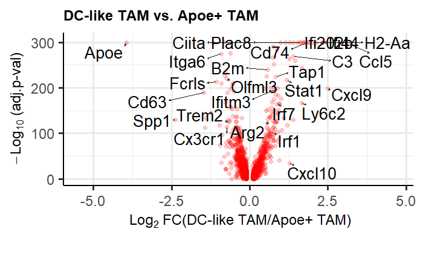

```r
#CD274 is PDL1
EnhancedVolcano(tamdcvapo,lab=rownames(tamdcvapo),x="avg_log2FC",y="p_val_adj",
                selectLab = c("H2-Aa","Spp1","Stat1","Irf7","Cd74","Ccl5","Cxcl9","Cxcl10","Ccl6","Ccl9", "Vcam1", "Cd83",
                              "C3","Apoe","Cd63","Itga6","Ly6c2","Trem2","Mrc1","Arg1", "C1qa",
                              "Cd9","Ciita","B2m","Tap1","Stat1","Ifi44","Ifi202b","Ifitm3",
                              "Fcrls","Olfml3","Sell","Plac8","Arg2","Irf1","Hif1a","Nos2","Il18bp","Cd47","Cx3cr1","Ccr2","Cd40",
                              "Nfkbia","Egr1","Lpl","Cd63","Ctsl","Cd68","Cadm1","Timp2","Card9"),
                pCutoff = NA,FCcutoff = NA,drawConnectors = T, title = "DC-like TAM vs. Apoe+ TAM",
                subtitle = NULL, legendPosition = "none", col = c("red","red","red","red"),colAlpha = .2,ylab = bquote(~-Log[10]~"(adj.p-val)"),
                xlab =bquote(~Log[2]~"FC(DC-like TAM/Apoe+ TAM)") ,caption = "", labSize = 7)
ggsave("KOvWTMacVolc.pdf",width = 7, height = 4,scale = 2)
```

Violin Plot for selected features for DC-like TAM,Apoe+ TAM, and Nos2+ TAM

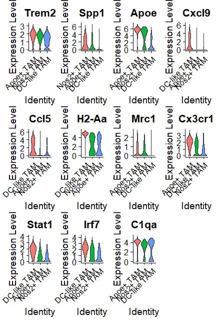

```r
VlnPlot(tam.ct2a,features = c("Trem2","Spp1","Apoe","Cxcl9","Ccl5","H2-Aa","Mrc1","Cx3cr1","Stat1","Irf7","C1qa"), sort = "increasing", pt.size = 0)
```

### Calculating Module score: Disease Associated Microglia

Using genes pulled from FigS5 Upregulated DAM4E

```r
consdam <- list(c("Trem2","Apoe","Spp1","Cd63","Cd9","Axl","Tyrobp","Ctsb","Fth1","Lpl","Cst7"))
```

Subset of m.ct2a for Mononuclear Phagocytes (MNPs)

```r
mnps <- subset(m.ct2a, idents = c("cMono","Nos2+ TAM","Apoe+ TAM","DC-like TAM","non-cMono", "Microglia"))
l <- c("Microglia","Apoe+ TAM","Nos2+ TAM","DC-like TAM","cMono","non-cMono")
Idents(mnps) <- factor(Idents(mnps),levels = l)
mnps$Genotype <- factor(mnps$Genotype,levels = c("WT","Camkk2KO"))
```

Visualization of conserved DAM gene features for MNPs (S5a)

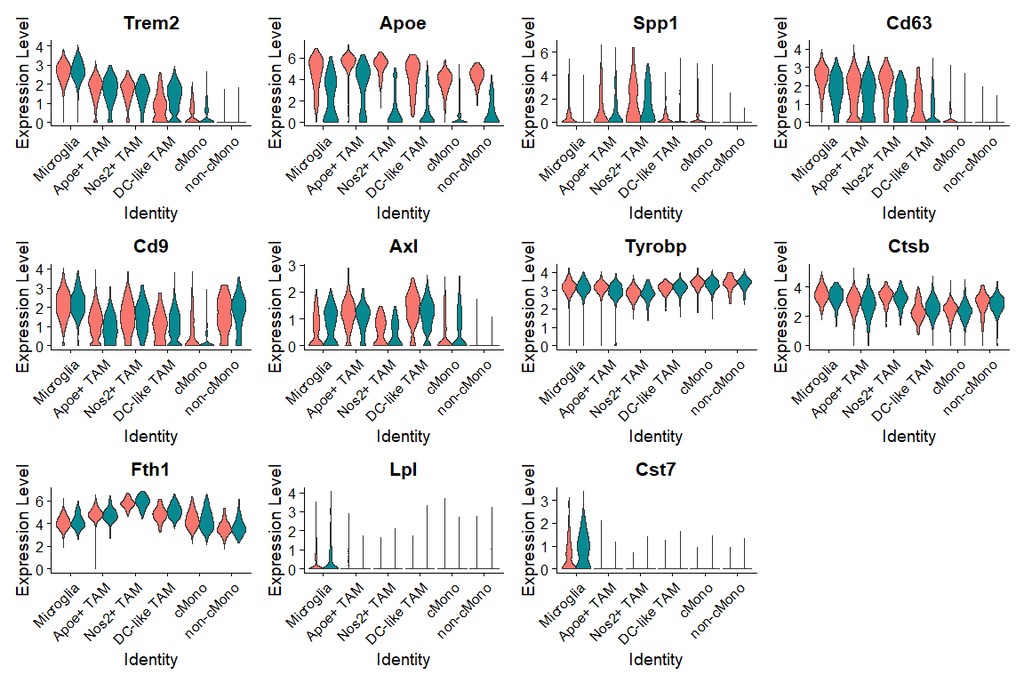

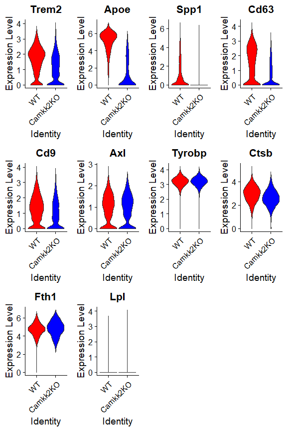

Calculation of module score for above mentioned genes

```r
m.ct2a <- AddModuleScore(m.ct2a,consdam,name = "DAM_Genes_Cons", assay = "RNA")
```

### Visualization of Conserved DAM Genes

(Fig 6c)

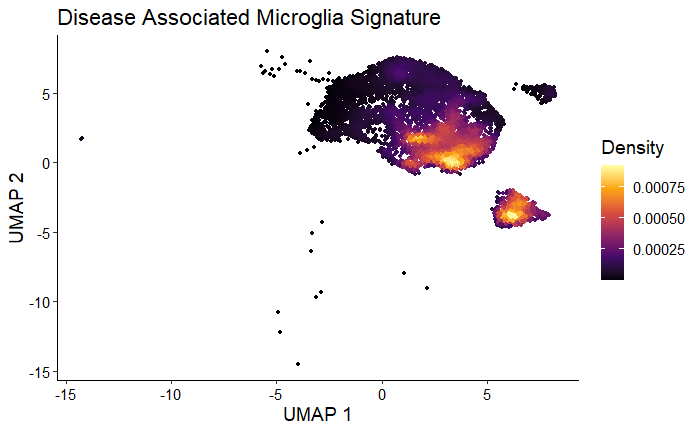

```r
plot_density(subset(m.ct2a, idents = c("cMono","Nos2+ TAM","Apoe+ TAM","DC-like TAM","non-cMono", "Microglia")),
             features = "DAM_Genes_Cons1", pal = "inferno",method = "wkde") +
  labs(title = "Disease Associated Microglia Signature")
ggsave("DAMFeatPlot.pdf",width = 3,height = 3,scale = 3)
```

### Expression Levels for Conserved DAM Genes for selected cell types

(Fig 6d)

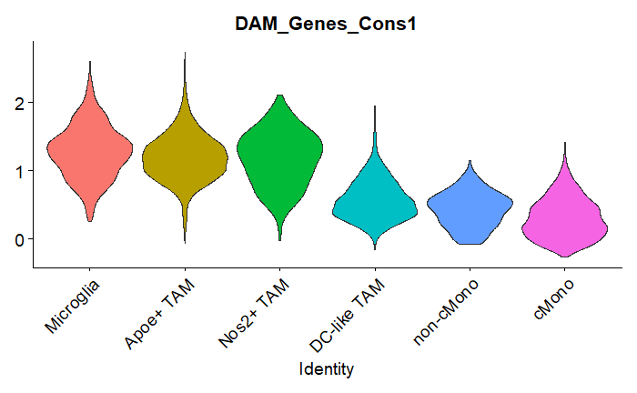

```r
VlnPlot(subset(m.ct2a, idents = c("cMono","Nos2+ TAM","Apoe+ TAM","DC-like TAM","non-cMono", "Microglia")),
        features = "DAM_Genes_Cons1", sort = "increasing", pt.size = 0) +
  theme(legend.position = "none", text = element_text(size = 14), axis.text = element_text(size = 14))
```

## V. Reclustering TILs

Subsetting Tumor-Infiltrating Lymphocytes (TILs) from the main object

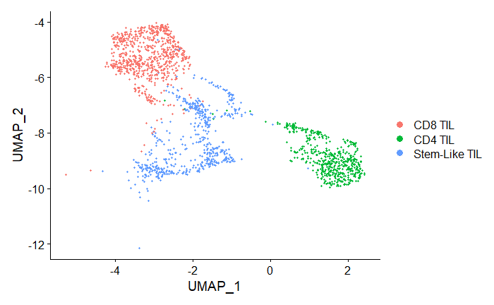

```r
tils <- subset(m.ct2a,idents = c("CD8 TIL","CD4 TIL","Stem-Like TIL"))
DimPlot(tils)
```

### Tcf7-Slamf6 Expression Correlate

Investigating the relationship between Tcf7 and Slamf6 expression.

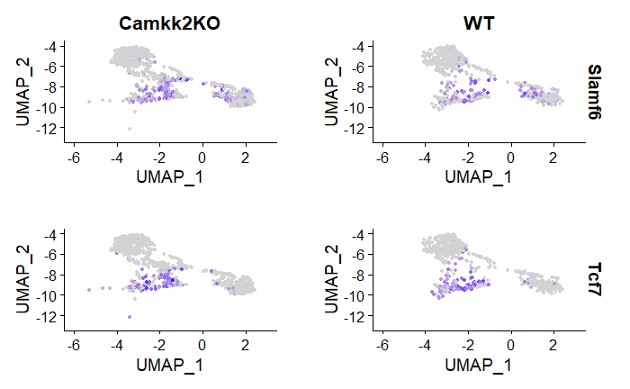

```r
FeaturePlot(tils, features = c("Slamf6","Tcf7"), split.by = "Genotype")
```

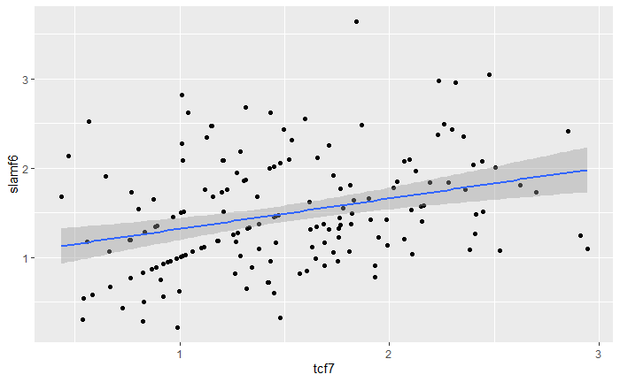

```r
til.count <- GetAssayData(tils, slot = "data", assay = "RNA")
slamf6.count <- til.count["Slamf6",]
tcf7.count <- til.count["Tcf7",]
til.counts <- data.frame(tcf7 = tcf7.count, slamf6 = slamf6.count)
til.counts <- til.counts %>%  filter(tcf7 != 0 & slamf6 != 0)
ggplot(til.counts, aes(tcf7, slamf6)) + geom_point() + geom_smooth(method = "lm")
```

```r
til.lm <- lm(tcf7 ~ slamf6, data = til.counts)
summary(til.lm)
```

```
Call:
lm(formula = tcf7 ~ slamf6, data = til.counts)

Residuals:
     Min       1Q   Median       3Q      Max
-1.22241 -0.40222 -0.04047  0.38606  1.54796

Coefficients:
            Estimate Std. Error t value Pr(>|t|)
(Intercept)  1.09180    0.10813  10.097  < 2e-16 ***
slamf6       0.27650    0.06691   4.132 5.72e-05 ***
---
Signif. codes:  0 ‘***’ 0.001 ‘**’ 0.01 ‘*’ 0.05 ‘.’ 0.1 ‘ ’ 1

Residual standard error: 0.5394 on 164 degrees of freedom
Multiple R-squared:  0.0943,    Adjusted R-squared:  0.08877
F-statistic: 17.07 on 1 and 164 DF,  p-value: 5.717e-05
```